# Car Selling Price

Hugh Miller

2023-01-06

## How Much Should I Get from Selling my Car?

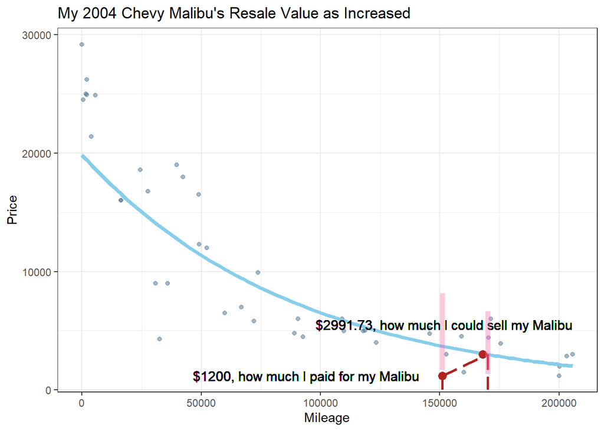

```r
library(tidyverse)
library(pander)

# load in data and make column name R friendly
cardata <- rio::import("malibu.xlsx")

# create regression
log.lm <- lm(log(Price) ~ Mileage, data=cardata)
b.log <- coef(log.lm)

# create prediction interval for when to sell my car
pred.u.log <- exp(predict(log.lm, data.frame(Mileage=170000), interval="prediction"))

## creat prediction interval for when I bought my car
pred.u.log2 <- exp(predict(log.lm, data.frame(Mileage=151000), interval="prediction"))

# plot regression
ggplot(cardata, aes(x = Mileage, y = Price)) +
  geom_point(size = 1.5, color = "skyblue4", alpha = 0.5) +
  stat_function(fun=function(x) exp(b.log[1] + b.log[2]*x), color="skyblue", size=1.5) +
  geom_segment(x = 170000, y = 2991.733, xend = 170000, yend = 0,
               linewidth = 1, color = "firebrick", linetype ="longdash", alpha = 0.5) +
  geom_segment(x = 151000, y = 1200, xend = 151000, yend = 0,
               linewidth = 1, color = "firebrick", linetype ="longdash", alpha = 0.5) +
  geom_segment(x = 151000, y = 1200, xend = 170000, yend = 2991.733,
               linewidth = 1, color = "firebrick", linetype ="longdash", alpha = 0.5) +
  geom_point(x = 168000, y = 2991.733, size = 3, color = "firebrick") +
  geom_point(x = 151000, y = 1200, size = 3, color = "firebrick") +
  geom_text(x = 168000, y = 3356.673, label = "$2991.73, how much I could sell my Malibu", color = "black", size = 4, vjust=-2, hjust=.65) +
  geom_text(x = 151000, y = 1200, label = "$1200, how much I paid for my Malibu", color = "black", size = 4, hjust=1.1) +
  geom_segment(aes(x=170000,xend=170000, y=pred.u.log[2], yend=pred.u.log[3]), alpha=0.01, lwd=2, col="hotpink") +
  geom_segment(aes(x=151000,xend=151000, y=pred.u.log2[2], yend=pred.u.log2[3]), alpha=0.01, lwd=2, col="hotpink") +
  theme_bw() +
  labs(title = "My 2004 Chevy Malibu's Resale Value as Increased", x = "Mileage", y = "Price")
```

The graph above plots the selling price for Chevy Malibu LTs based on the mileage at the time of the sale. As one would probably expect, the selling price for Malibus decreases as the mileage increases. Towards the bottom of the graph a red point plots the price I paid for my 2004 Chevy Malibu. I bought it at 151000 miles for just 1200. I plan to sell the car once it hits around 170000, and according to the regression I should be able to sell it for around 2991 - over doubling my money. This can probably be owed to the fact that Post-Covid supply chain issues have increased the demand for used vehicles.

## Background and Hypotheses

The aim of this analysis is to show that there is a negative relationship between a car’s mileage and car’s selling price - the greater the mileage, the less it will sell for.

As will be demonstrated shortly, it was found that doing a logarithmic transformation to the price variable helped produced the best fit regression line for the data. Therefore, the equation for our model is:
$$\underbrace{Y_i}_\text{Selling Price} = e^{\beta_0 +\beta_1 X_i +
\epsilon_i} = e^{\beta_0}e^{\beta_1 X_i}e^{\epsilon_i}$$
$$\text{Where} X_i \text{is the number of miles driven}$$

Our null hypothesis is that there is no correlation between a car’s mileage and a car’s selling price and that ($\beta_1$) is 0 (which means the resale value of a car would never change no matter how long you drove it).

$$H_0: \beta_1 = 0$$
Our alternative hypothesis is that there is a correlation between a car’s mileage and its selling price and that $\beta_1$ is not 0 (meaning each additional mile a car is driven will have an effect on its value).

$$H_a: \beta_1 \neq 0$$
$\alpha$ = 0.05 is the level of significance we will use in the linear regression test.

## Data Used

The data used for this regression was collected using a variety of car listings for Chevy Malibus currently on sale. These listings were primarily found on [carfox.com](https://www.carfax.com/Used-2004-Chevrolet-Malibu_z3728), [edmunds.com](https://www.edmunds.com/chevrolet/malibu/2004/), and [autolist.com](https://www.autolist.com/chevrolet-malibu-2004#year_min=2004&year_max=2004&make=Chevrolet&model=Malibu&location=98014&latitude=47.621239&longitude=-121.842349&radius=any&page=1&sort_new_cars_last=true).

```r
pander(cardata)
```

| Mileage | Price |
| --- | --- |
| 159101 | 4537 |
| 160000 | 1500 |
| 2e+05 | 1200 |
| 90659 | 5995 |
| 200222 | 1995 |
| 152713 | 2995 |
| 30906 | 8990 |
| 109023 | 5995 |
| 72057 | 5800 |
| 89000 | 4800 |
| 35906 | 8990 |
| 109775 | 4995 |
| 117878 | 4995 |
| 171452 | 5995 |
| 59837 | 6479 |
| 170447 | 4400 |
| 123356 | 3995 |
| 145707 | 4766 |
| 73766 | 9900 |
| 145625 | 5222 |
| 92585 | 4490 |
| 118578 | 4999 |
| 66789 | 6995 |
| 0 | 29195 |
| 2015 | 26226 |
| 5557 | 24881 |
| 2106 | 24922 |
| 554 | 24505 |
| 1650 | 24999 |
| 16398 | 15998 |
| 52286 | 12000 |
| 48889 | 16500 |
| 16398 | 15998 |
| 49101 | 12300 |
| 39668 | 18998 |
| 3961 | 21406 |
| 42364 | 17995 |
| 27667 | 16786 |
| 24401 | 18590 |
| 175622 | 3900 |
| 32465 | 4295 |
| 203255 | 2850 |
| 205725 | 2995 |

## Finding the Right Fit for the Data

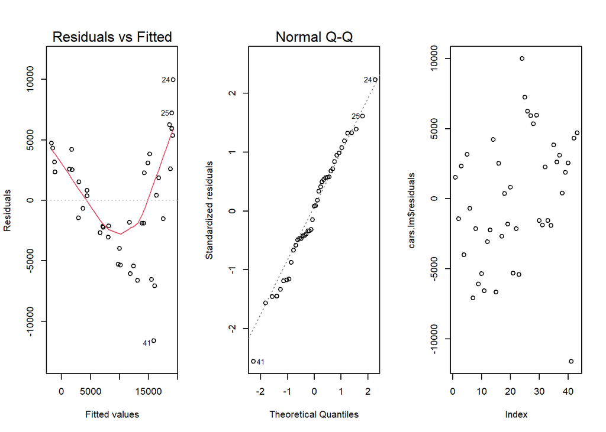

```r
cars.lm <- lm(Price ~ Mileage, data=cardata)

par(mfrow=c(1,3))
plot(cars.lm, which=1:2)
plot(cars.lm$residuals)
```

As mentioned when showing the equation of this model, we found that a transformation of the price data was necessary in finding the best fit line for the analysis. Below is the results of a Box-Cox analysis that was performed on the cars data.

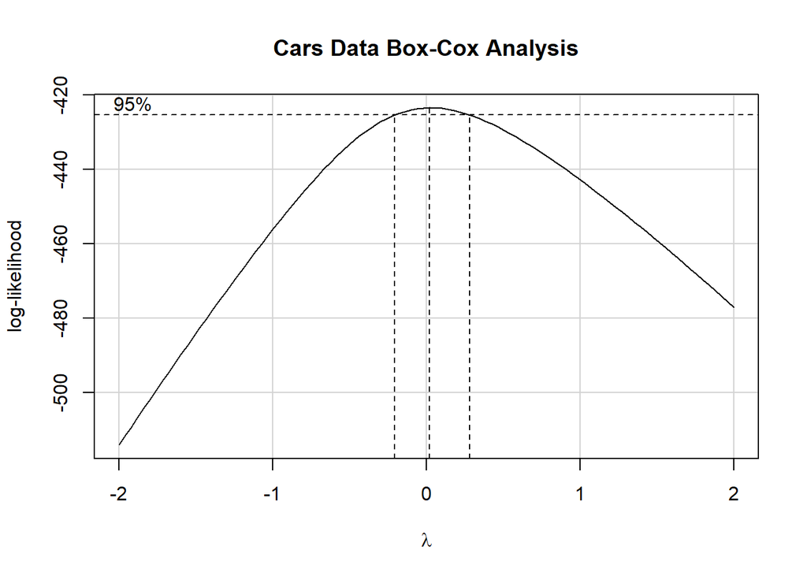

```r
library(car)
boxCox(cars.lm, main="Cars Data Box-Cox Analysis")
```

The middle dotted band indicates a lambda value very close to 0, which is interpreted to mean that a logarithmic transformation needs to be done to the price variable in our regression analysis. The results of said regression analysis can be seen below:

```r
pander(summary(log.lm))
```

|  | Estimate | Std. Error | t value | Pr(>\|t\|) |
| --- | --- | --- | --- | --- |
| **(Intercept)** | 9.897 | 0.09494 | 104.2 | 2.408e-51 |
| **Mileage** | -1.114e-05 | 8.836e-07 | -12.6 | 1.094e-15 |

Fitting linear model: log(Price) ~ Mileage

| Observations | Residual Std. Error | $R^2$ | Adjusted $R^2$ |
| --- | --- | --- | --- |
| 43 | 0.3824 | 0.7948 | 0.7898 |

```r
exp(b.log[2]*1000)
```

```
##   Mileage
## 0.9889259
```

These results coincide with the results of the Box-Cox analysis and show that the logarithmic transformation of the price data created a more meaningful regression. We have an extremely low p-value that is well below our level of significance of $\alpha = 0.05$, which allows us to reject the null hypothesis and conclude that the selling price of Malibus and their mileage are not independent factors.

The slope is a very low negative value, which means that with each additional mile put on a Malibu, most of its value is retained. However, the value does diminish slightly and the effect becomes more evident over time.

Since we did a log transformation on the selling prices, we can actually come up with a percentage (or proportion) of the amount of value is retained with each 1000 miles of driving. This is done by calculating $e^{slope \times 1000}$. This calculation tells us that 98.89259% of the cars value is retained with each 1000 miles driven.

## When is the best time to sell my Car?

According to the regression model, I got my 2004 Chevy Malibu at a pretty good price. I bought it at 151,000 miles for just 1200, while according to the regression the resale value at that mileage for the car was 3696.68. I plan to sell that car once it gets to around the 170000 and according to the regression, I could sell it at this point for around 2991.73. The cost per mile in the scenario is calculated as follows:
$$\underbrace{cpm}_\text{Cost per mile} = \frac{3696.68-2991.73}{19000} =
\underbrace{0.0371}_\text{approx. 3.7 cents per mile}$$

By selling at the 170000, I’m projected experience a 3.7 cent decrease in the resell value of my car per mile it’s driven. This appears to be a good time to sell, since a Malibu’s lifespan seems to last until a little over the 200,000 mile mark. Even if I waited up until the 200,000 mile mark (assuming it lasts that long), the improvement in my cost per mile is relatively small as demonstrated; the regression projects the selling price would be around $2142.08 at the point:

$$\underbrace{cpm}_\text{Cost per mile} = \frac{3696.68-2142.08}{49000} =
\underbrace{0.0317}_\text{approx. 3.17 cents per mile}$$

```r
# create prediction interval for when to sell my car
library(pander)

pander(pred.u.log <- exp(predict(log.lm, data.frame(Mileage=170000), interval="prediction")))
```

| fit | lwr | upr |
| --- | --- | --- |
| 2992 | 1350 | 6631 |

The prediction interval gives a range from $1350 to $6631 for the selling price of a Malibu with 170,000 miles. This is a smaller interval than the one at 151000 miles. The data becomes less varied as the mileage increases.

```r
## creat prediction interval for when I bought my car
pander(pred.u.log2 <- exp(predict(log.lm, data.frame(Mileage=151000), interval="prediction")))
```

| fit | lwr | upr |
| --- | --- | --- |
| 3697 | 1678 | 8146 |

The price I paid for my car, $1200, is well out of the prediction interval for car at 151,000. This interval bottoms out at $1678. Ir is a very large residual.